# Test 3

- Show All Code
- Hide All Code
- View Source

Author

Danyili Hong

# Data and Sort

```r
ebola <- read_csv('https://sldr.netlify.app/data/ebola-WASH.csv', show_col_types = FALSE) |>
select(PPEDamaged, Occupancy, HighChlorine, Month,Week) |>
na.omit()
nrow(ebola)/15
```

```
[1] 8.066667
```

```r
ebola <- ebola |>
  arrange(Week)
```

According to the n/15 rule, I can have estimated 8 parameters for this dataset, but it turns out having 11 parameters. Even though it’s more than the estimated amount, I think all of the parameters are important so I kept them.

# Rationale

I included Week as my random effect. I chose Week because it is one of the variables to track time and the measurements were taken repeatedly over time. I also have estimated 8 parameters that I can include for this dataset, but since my original dateset has already surpassed 8 parameters so I decided only include one random effect.

# Fit the Model

```r
# Fit the Model
nb1_re <- glmmTMB(PPEDamaged ~ Occupancy*Month + HighChlorine + (1|Week), data = ebola, family = nbinom1(link = 'log'))
nb2 <- glmmTMB(PPEDamaged ~ Occupancy*Month + HighChlorine + (1|Week), data = ebola, family = nbinom2(link = 'log'))
AIC(nb1_re, nb2)
```

```
       df      AIC
nb1_re 13 508.6309
nb2    13 509.3216
```

# Summary

```r
summary(nb1_re)
```

```
 Family: nbinom1  ( log )
Formula:          PPEDamaged ~ Occupancy * Month + HighChlorine + (1 | Week)
Data: ebola

     AIC      BIC   logLik deviance df.resid
   508.6    545.0   -241.3    482.6      108

Random effects:

Conditional model:
 Groups Name        Variance Std.Dev.
 Week   (Intercept) 0.05208  0.2282
Number of obs: 121, groups:  Week, 19

Dispersion parameter for nbinom1 family (): 2.58

Conditional model:
                     Estimate Std. Error z value Pr(>|z|)
(Intercept)         4.758e-01  9.067e-01   0.525   0.5997
Occupancy          -1.447e-01  1.259e-01  -1.149   0.2504
MonthDec            1.793e+00  1.057e+00   1.696   0.0899 .
MonthFeb           -6.497e-01  9.332e-01  -0.696   0.4863
MonthJan           -1.063e+00  1.045e+00  -1.018   0.3088
MonthMar           -3.109e-01  1.048e+00  -0.297   0.7667
HighChlorine        8.798e-05  8.901e-05   0.989   0.3229
Occupancy:MonthDec  1.284e-01  1.417e-01   0.906   0.3649
Occupancy:MonthFeb  1.470e-01  1.268e-01   1.159   0.2464
Occupancy:MonthJan  3.151e-01  1.438e-01   2.191   0.0284 *
Occupancy:MonthMar  1.435e-01  1.284e-01   1.118   0.2635
---
Signif. codes:  0 '***' 0.001 '**' 0.01 '*' 0.05 '.' 0.1 ' ' 1
```

The random effect variance is 0.05208 which is very small. It means that there is little variability in PPEDamaged between different weeks after accounting for fixed effects.

# Assessment

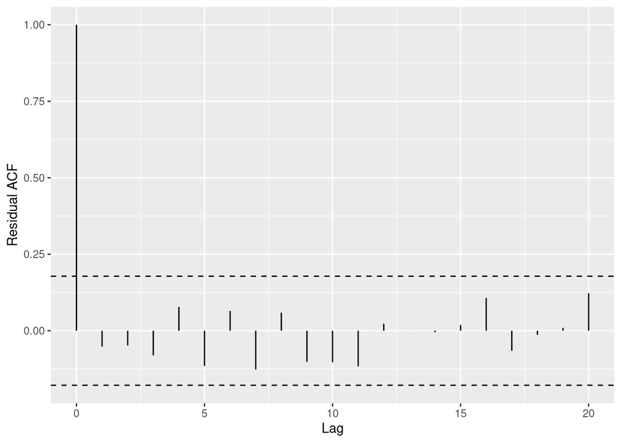

```r
nb1 <- glmmTMB(PPEDamaged ~ Occupancy*Month + HighChlorine, data = ebola, family = nbinom1(link = 'log'))
s245::gf_acf(~resid(nb1_re))
```

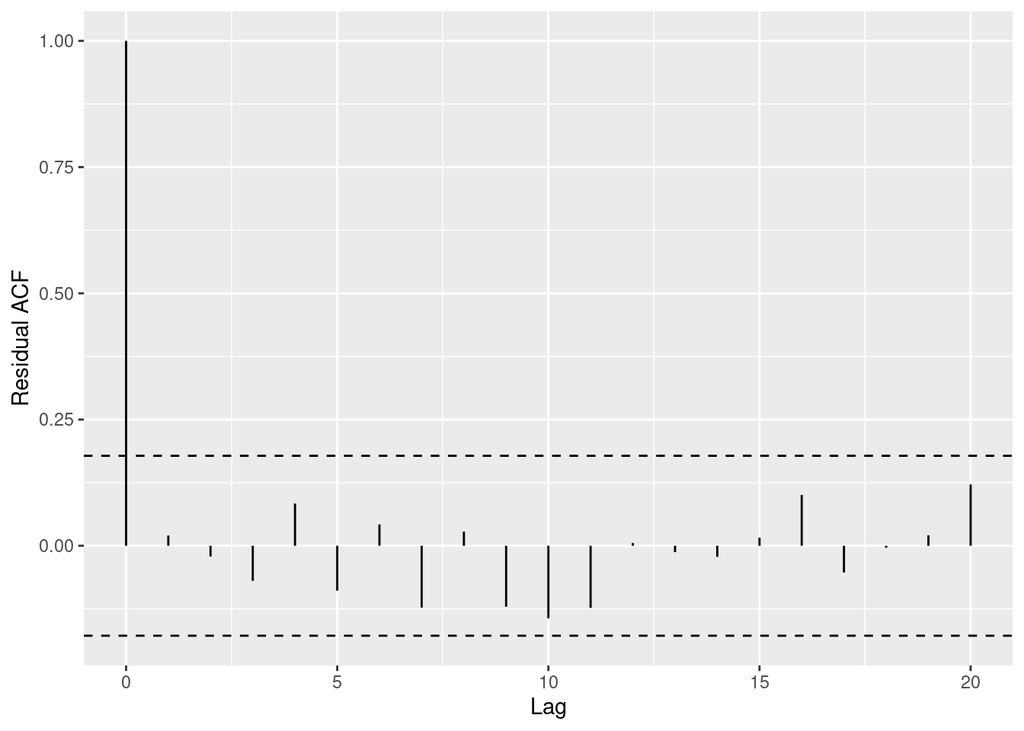

```r
s245::gf_acf(~resid(nb1))
```

By comparing two ACF plots, one with random effect and one without, both of them only have one lag poking out of the confidence bound so I would say both of them met the residual independence condition. From my ACF plots, adding random effect didn’t really affect the residual independence.